# Diary

# Now I have the line matplot but I am still learning to customize it more properly. I have class on plots next week on November 19th, so I hope to learn there. Now I am gonna change everything in to line graphs and add titles

Here X1M

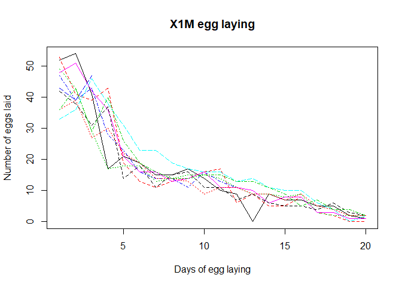

```r
y <- y <- egg_data[2:11]
# print(y)
matplot(egg_data$Days_of_egg_laying,y, type='l', xlab = 'Days of egg laying', ylab = 'Number of eggs laid', main = 'X1M egg laying')
```

Here X2M

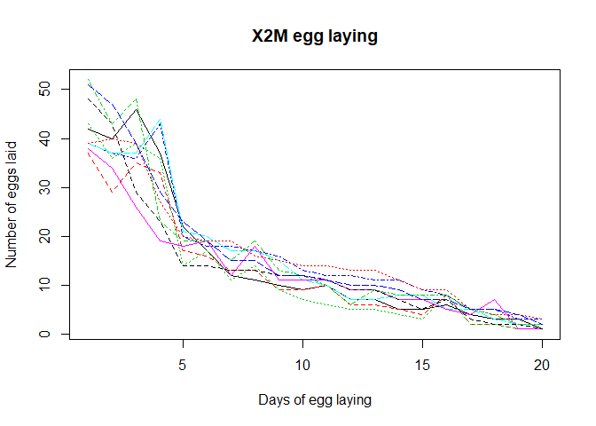

```r
y <- egg_data[12:21]
# print(y)
matplot(egg_data$Days_of_egg_laying,y, type='l', xlab = 'Days of egg laying', ylab = 'Number of eggs laid', main = 'X2M egg laying')
```

Here X3M

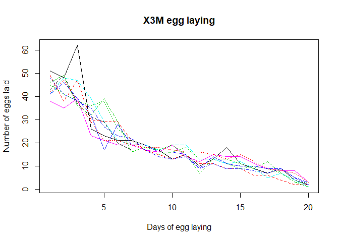

```r
y <- egg_data[22:31]
# print(y)
matplot(egg_data$Days_of_egg_laying,y, type='l', xlab = 'Days of egg laying', ylab = 'Number of eggs laid', main = 'X3M egg laying')
```

Here C

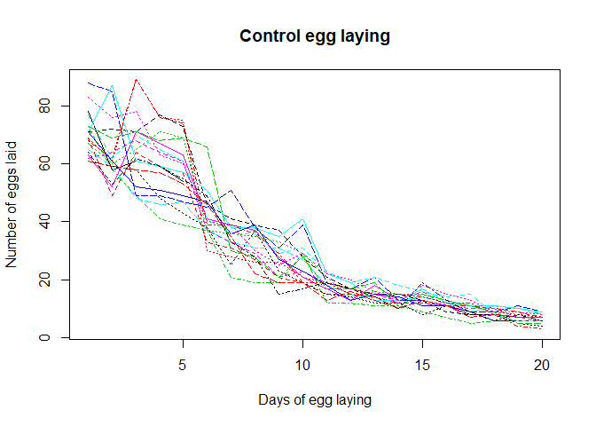

```r
y <- egg_data[32:51]
# print(y)
matplot(egg_data$Days_of_egg_laying,y, type='l', xlab = 'Days of egg laying', ylab = 'Number of eggs laid', main = 'Control egg laying')
```

*** Total eggs laid ***  
One measure of the female’s fecundity is the total number of eggs laid, obtained from the number of eggs per day summed from day 1 to 20 (female age 3 to 23 days post-eclosion). This I obtained using numbers (excel) and coverted to a .cvs file, loaded here.

```r
total_egg_data <- read.csv("total_eggs.csv",header=TRUE)
#print(str(total_egg_data))
#print("column names")
#print(names(total_egg_data))
print(head(total_egg_data,n=20L))
```

```
##    Female X1M X2M X3M   C
## 1       1 320 297 399 310
## 2       2 317 256 363 545
## 3       3 300 263 390 636
## 4       4 275 336 361  77
## 5       5 368 315 393 547
## 6       6 335 267 354 597
## 7       7 291 277 226 674
## 8       8 292 333 384 619
## 9       9 335 325 392 470
## 10     10 129 332 368 654
## 11     11  NA  NA  NA 675
## 12     12  NA  NA  NA 586
## 13     13  NA  NA  NA 508
## 14     14  NA  NA  NA 650
## 15     15  NA  NA  NA 645
## 16     16  NA  NA  NA 565
## 17     17  NA  NA  NA 654
## 18     18  NA  NA  NA 665
## 19     19  NA  NA  NA 556
## 20     20  NA  NA  NA 534
```

The columns are the four different “experiments”, !M, 2M, 3M, C The rows are the different females (observations of female fecundity as measured by total eggs laid). There are 10 observations for 1M, 2M, 3M and 20 for C.

Next do a boxplot of this data

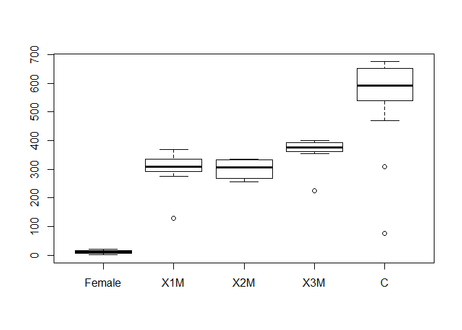

```r
boxplot(total_egg_data)
```

The “Female” column is ignored (just female number). The other boxplots show 4 outliers. These are the 4 females that died before the full 20 days.

```r
total_egg_revised_data <- read.csv("total_eggs_revised.csv",header=TRUE)
#print(str(total_egg_revised_data))
#print("column names")
#print(names(total_egg_revised_data))
print(head(total_egg_revised_data,n=18L))
```

```
##    Female X1M X2M X3M   C
## 1       1 320 297 399 545
## 2       2 317 256 363 636
## 3       3 300 263 390 547
## 4       4 275 336 361 597
## 5       5 368 315 393 674
## 6       6 335 267 354 619
## 7       7 291 277 384 470
## 8       8 292 333 392 654
## 9       9 335 325 368 675
## 10     10  NA 332  NA 586
## 11     11  NA  NA  NA 508
## 12     12  NA  NA  NA 650
## 13     13  NA  NA  NA 645
## 14     14  NA  NA  NA 565
## 15     15  NA  NA  NA 654
## 16     16  NA  NA  NA 665
## 17     17  NA  NA  NA 556
## 18     18  NA  NA  NA 534
```

Next do a boxplot of this data

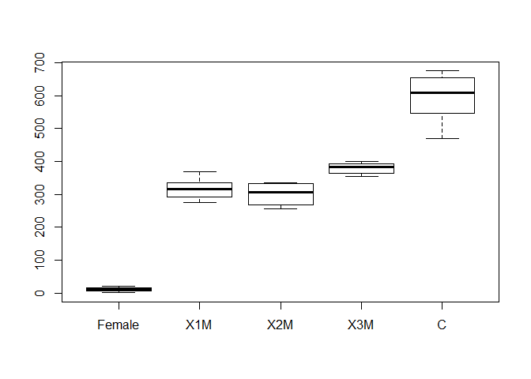

```r
boxplot(total_egg_revised_data)
```

Now the data looks resonable for analysis of variance.

Its just a little what I have applied to my own data because of short of time. But its a good thing to practice. Thank you.